# Problem 3 of recommended exercise 5

S. Muff

07 Februar, 2022

## Selection bias and the “wrong way to do CV”.

### Generate data

- Simulate high dimensional data ($p=5000$ predictors) from independent or correlated normal variables, but with few samples ($n=50$).
- Randomly assign class labels (here only 2). This means that the “truth”" is that the misclassification rate can not get very small. What is the expected misclassification rate (for this random set)?

### Classification task:

We start by generating data for $n=50$ observations

```r
library(boot)
```

GENERATE DATA; use a seed for reproducibility

```r
set.seed(4268)
n=50 #number of observations
p=5000 #number of predictors
d=25 #top correlated predictors chosen
```

Generating predictor data

```r
xs=matrix(rnorm(n*p,0,4),ncol=p,nrow=n) #simple way to to uncorrelated predictors
dim(xs) # n times p
```

```
## [1]   50 5000
```

```r
xs[1:10,1:10]
```

```
##             [,1]       [,2]       [,3]        [,4]       [,5]       [,6]
##  [1,]  2.8125105 -3.3689129  5.5747767 -3.04928753  0.8555066 -1.1050346
##  [2,] -1.8544420  3.1645298 -0.3671258  1.44950459 -0.5411102 -5.4423137
##  [3,] -3.3080368 -3.9930962  2.6204346 -0.25217061 -4.3538633 -3.7710933
##  [4,] 10.2366356 -0.7164228 -1.3666231 -1.32187315  4.7942956  0.8779834
##  [5,]  4.5156195  1.3050011 -3.8723070  7.39712557  2.3255667  3.8019991
##  [6,]  0.2165955  4.6140897 -2.4021400 -3.77228778 -2.1104860  3.2755725
##  [7,] -1.5353951  1.4099929 -3.5141717  9.99984725 -3.6088718 -1.5373765
##  [8,]  9.5894632  1.4670509  2.3137443 -0.05175731 -5.9917612 -2.0993797
##  [9,] -0.6402175 -5.6600206 -2.2497551 -3.08858263 -2.4483644  0.5098223
## [10,] -0.8868698 -2.5134161 -5.8847008  0.32438061 -1.2514283 -1.7512387
##             [,7]       [,8]       [,9]      [,10]
##  [1,] -0.2422857 -2.9429372  8.6247697 -2.3357772
##  [2,]  7.3053909  3.0751592  2.5372712  5.0410480
##  [3,] -3.5043736  0.7919591 -4.9973899  7.8313380
##  [4,]  2.7266669 -0.3263267  2.1958517  2.8299448
##  [5,] -0.2525857 -1.7202598 -0.3899012 -0.4330239
##  [6,]  5.9126109  0.9877965  2.7697640  0.4252308
##  [7,] -0.1940503  4.7697556  2.3852673  0.3964231
##  [8,] -2.0928086  5.0020511  3.1798056 -0.5821753
##  [9,] -3.4868391 -2.1553372 -1.2674482  3.8649200
## [10,]  1.3292362 -3.0534881 -0.7671551 -4.7029797
```

Generate class labels independent of predictors - so if all classifies as class 1 we expect 50% errors in general

```r
ys=c(rep(0,n/2),rep(1,n/2)) #now really 50% of each
table(ys)
```

```
## ys
##  0  1
## 25 25
```

## *WRONG CV*:

Select the 25 most correlated predictors outside the CV.

Calculate the correlations for all predictors and the response

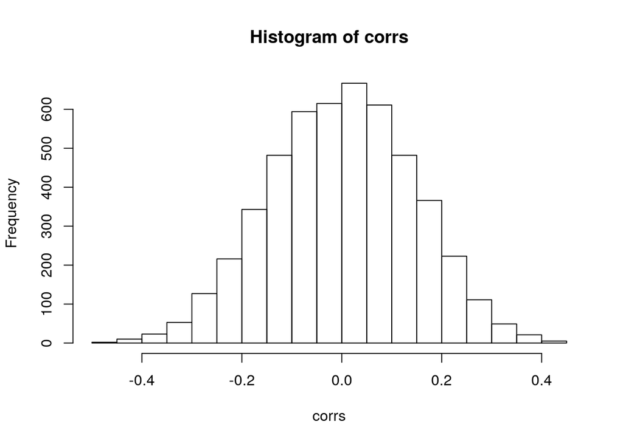

```r
corrs=apply(xs,2,cor,y=ys)
hist(corrs)
```

Select the d predictors with the highes correlation

```r
selected=order(corrs^2,decreasing = TRUE)[1:d]
```

Then store the highest correlated predictors into a reduced data frame, together with the response y:

```r
data=data.frame(ys,xs[,selected])
```

Then run CV around the fitting of the classifier - use logistic regression and built in `cv.glm()` function

```r
logfit=glm(ys~.,family="binomial",data=data)

cost <- function(r, pi = 0) mean(abs(r-pi) > 0.5)
kfold=10

cvres=cv.glm(data=data,glmfit=logfit,cost=cost,K=10)
cvres$delta
```

```
## [1] 0 0
```

Observe a zero misclassification rate!

## *CORRECT CV*

Do not pre-select predictors outside the CV, but as part of the CV. We need to code this ourselves:

```r
reorder=sample(1:n,replace=FALSE)
validclass=NULL
for (i in 1:kfold)
{
  neach=n/kfold
  trainids=setdiff(1:n,(((i-1)*neach+1):(i*neach)))
  traindata=data.frame(xs[reorder[trainids],],ys[reorder[trainids]])
  validdata=data.frame(xs[reorder[-trainids],],ys[reorder[-trainids]])
  colnames(traindata)=colnames(validdata)=c(paste("X",1:p),"y")
  foldcorrs= apply(traindata[,1:p],2,cor,y=traindata[,p+1])
  selected=order(foldcorrs^2,decreasing = TRUE)[1:d] #top d correlated selected
  data=traindata[,c(selected,p+1)]
  trainlogfit=glm(y~.,family="binomial",data=data)
  pred=plogis(predict.glm(trainlogfit,newdata=validdata[,selected]))
  validclass=c(validclass,ifelse(pred > 0.5, 1, 0))
}
table(ys[reorder],validclass)
```

```
##    validclass
##      0  1
##   0  9 16
##   1 12 13
```

```r
1-sum(diag(table(ys[reorder],validclass)))/n
```

```
## [1] 0.56
```